# Quick and Tidy Guide to Econometrics

Ryan Safner

Fall 2019

# Overview

This is a quick guide to using `R` for basic econometrics and data analysis tasks (i.e. manipulating data, running regressions, and making plots and tables) in an *opinionated* way, using the `tidyverse` packages and grammar. Use this as document a shortcut or cheatsheet to refer to the packages, commands, and syntax necessary to perform these tasks.

It is wise to always **load tidyverse**[^1] at the beginning of each R session or markdown document, as most of the guide makes use of packages and commands that are *assumed* to already be loaded with tidyverse.

```r
library(tidyverse)
```

Throughout this guide, I use an `example_data.csv` file for data. To see how I made this data with `R`, see the Appendix.

# Summary Cheatsheet

### General Tips

- Make an R Project to organize files
- Always start with `library(tidyverse)`
- Never `View()` or `install.packages()` in a `.Rmd` file

### Data Import

`df<-read_*("file.*")`

### Data Wrangling

| Command | Does | Example |
| --- | --- | --- |
| `select()` | Keep desired columns (variables) | `gapminder %>% select(pop)` |
| `filter()` | Keep desired rows (observations) | `gapminder %>% filter(country=="France")` |
| `arrange()` | Reorder rows (e.g. in numerical order) | `gapminder %>% arrange(pop)` |
| `mutate()` | Create new variables | `gapminder %>% mutate(GDP = gdpPerCap * pop)` |
| `summarize()` | Collapse data into summary statistics | `gapminder %>% summarize(avg_GDP = mean(gdpPerCap))` |
| `group_by()` | Perform any of the above functions by groups/categories | `gapminder %>% group_by(country) %>% summarize(avg_LE = mean(LifeExp))` |

### Regressions

`reg<-lm(y~x+z, data = df)`

- Extensions:
  - Polynomial: `I(var_name^2)`
  - Log: `log(var_name)`
  - Dummy/Fixed Effects (if not already a `factor` or dummy): `factor(category_var)`
  - Interaction: `var_1:var_2`
- Viewing:
  - `summary(reg)` for full output
  - `broom::tidy(reg)` to view coefficients in tidy tibble
  - `broom::glance(reg)` to view regression statistics in tidy tibble
  - `broom::augment(reg)` to add regression-based observations (i.e. $\hat{u_i}$, $\hat{Y_i})$
- Making Regression Tables:
  - `huxtable::huxreg(reg)`

### Plotting

```r
ggplot(data = df)+ # layer defining dataframe for data source
  # aesthetics layer to map variables to aesthetics
  aes(x = X,
      y = Y,
      color = shape)+ # will color by shape
  # geometries layer(s)
  geom_point()+
  geom_smooth(method = "lm") # add a regression line
```

# R Basics

- `R` is “object-oriented”:
  - *Assign* values in objects: `my_object<-my_values`
  - *Overwrite* objects: `my_object<-my_new_values`
  - *Run functions* on objects: `function_name(my_object)`
- Data types:
  - `numeric` (“`double`” or “`integer`”) data are numbers
    - can use for math and statistics
  - `character`: strings of text
    - values must always be `"in quotes"`
  - `factor`: indicates membership in one of several possible categories or groups
- Object types:
  - `vector`: collection of objects
    - create with `c()` function
  - `data.frame` or `tibble`: each row is a vector of same data type[^2]
    - rows are observations
    - columns are variables
- Packages:
  - *Install* any package with `install.packages(“package_name”)
    - Only necessary once, if package doesn’t already exist
  - *Load* a package for each session needed with `library("package_name")`
  - *Description of packages we use*:

| Package | Use |
| --- | --- |
| `tidyverse` | For tibbles (`tibble`), `%>%` operator (`magrittr`), data import (`readr`), data wrangling (`dplyr`), plotting (`ggplot2`) |
| `broom` | For tidy regression outputs |
| `huxtable` | For making regression tables |
| `car` | For regression tests (heteroskedasticity, outliers, F-test) |
| `lmtest` |  |
| `estimatr` | For regression with heteroskedasticity-robust standard errors |

# Data Wrangling

## Import

- Import data with `read_*()` where the `*` represents the file extension (e.g. `csv`, `tsv`, `xls`, `xlsx`, `dta`)[^3] and inside the parentheses you place the location of the file on your computer or web URL in quotes
- Be sure to assign your data to a tibble!

```r
#my_df<-read_csv("https://metricsf19.classes.ryansafner.com/data/example_data.csv")

my_df<-read_csv("example_data.csv")
```

## Looking at Data

- type the name of the tibble to print its contents
- `str()` gives the structure of a tibble
- `head()` prints the first few rows of a tibble
- `View()` will open the tibble in a separate window for inspection[^4]
- `glimpse()` gives the structure in a horizontal way

```r
my_df
```

| X | Z | U | Shape | Y |
| --- | --- | --- | --- | --- |
| 9.737951 | 10.76144 | 0.57631430 | Square | 9.5983924 |
| 11.785850 | 12.02853 | 0.99107639 | Circle | 2.5797834 |
| 10.334175 | 10.72002 | -0.78134698 | Circle | 4.9050850 |
| 9.028176 | 14.41761 | 0.41238420 | Triangle | 24.6735406 |
| 9.371203 | 18.03719 | -0.67469748 | Square | 34.4527179 |
| 10.272492 | 14.68002 | 1.22612217 | Square | 21.3891870 |
| 9.568665 | 17.43714 | -0.02483343 | Square | 32.4825115 |
| 10.740101 | 16.70255 | -0.74989568 | Circle | 24.6047291 |
| 9.709540 | 15.53710 | -0.54076231 | Square | 24.9923687 |
| 10.018759 | 15.00197 | -0.07723624 | Square | 22.3497797 |

[output cut: 90 more lines]

```r
str(my_df)
```

```
## Classes 'spec_tbl_df', 'tbl_df', 'tbl' and 'data.frame': 100 obs. of  5 variables:
##  $ X    : num  9.74 11.79 10.33 9.03 9.37 ...
##  $ Z    : num  10.8 12 10.7 14.4 18 ...
##  $ U    : num  0.576 0.991 -0.781 0.412 -0.675 ...
##  $ Shape: chr  "Square" "Circle" "Circle" "Triangle" ...
##  $ Y    : num  9.6 2.58 4.91 24.67 34.45 ...
##  - attr(*, "spec")=
##   .. cols(
##   ..   X = col_double(),
##   ..   Z = col_double(),
##   ..   U = col_double(),
##   ..   Shape = col_character(),
##   ..   Y = col_double()
##   .. )
```

```r
head(my_df)
```

| X | Z | U | Shape | Y |
| --- | --- | --- | --- | --- |
| 9.737951 | 10.76144 | 0.5763143 | Square | 9.598392 |
| 11.785850 | 12.02853 | 0.9910764 | Circle | 2.579783 |
| 10.334175 | 10.72002 | -0.7813470 | Circle | 4.905085 |
| 9.028176 | 14.41761 | 0.4123842 | Triangle | 24.673541 |
| 9.371203 | 18.03719 | -0.6746975 | Square | 34.452718 |
| 10.272492 | 14.68002 | 1.2261222 | Square | 21.389187 |

```r
glimpse(my_df)
```

```
## Observations: 100
## Variables: 5
## $ X     <dbl> 9.737951, 11.785850, 10.334175, 9.028176, 9.371203, 10.272492, …
## $ Z     <dbl> 10.76144, 12.02853, 10.72002, 14.41761, 18.03719, 14.68002, 17.…
## $ U     <dbl> 0.57631430, 0.99107639, -0.78134698, 0.41238420, -0.67469748, 1…
## $ Shape <chr> "Square", "Circle", "Circle", "Triangle", "Square", "Square", "…
## $ Y     <dbl> 9.598392, 2.579783, 4.905085, 24.673541, 34.452718, 21.389187, …
```

## General Data Manipulation

The following table provides the major verbs for manipulating data. Further sections below provide examples for i. *subsetting* data ii. *transforming* data iii. *summarizing* data

| Verb (from `dplyr`) | Action |
| --- | --- |
| `select()` | Keep desired columns (variables) |
| `filter()` | Keep desired rows (observations) |
| `arrange()` | Reorder rows (e.g. in numerical order) |
| `mutate()` | Create new variables |
| `summarize()` | Collapse data into summary statistics |
| `group_by()` | Perform any of the above functions by groups/categories |

Most verbs allow you to manipulate data according to some **condition(s)**. Popular operators for performing conditional operations are listed in the table below:

| Command | Effect |
| --- | --- |
| `<`; `>` | Less than; greater than |
| `<=`; `>=` | Less than or equal to; greater than or equal to |
| `==`; `!=` | Is equal to; is not equal to |
| `%in%` | Is in the set of [a vector of options] |
| `is.na()` | Is missing (`NA`) |

Finally, for each command, you can alternatively:

```r
# Just view the output
my_df %>% verb()

# Assign to a different object
my_df_2<-my_df %>% verb()
my_df_2 # then view the output

# Assign to the original object (and overwrite it)
my_df<-my_df %>% verb()
my_df # then view the output
```

## Subset Data

- To *subset* data and take only a portion of the data set by some condition(s) for various purposes, use
  - `select()` to subset by columns (variables)
  - `filter()` to subset by rows (observations)

```r
# look only at data for "circles" AND where X>10
my_df %>%
  filter(Shape=="Circle",
         X>10)
```

| X | Z | U | Shape | Y |
| --- | --- | --- | --- | --- |
| 11.78585 | 12.02853 | 0.99107639 | Circle | 2.5797834 |
| 10.33417 | 10.72002 | -0.78134698 | Circle | 4.9050850 |
| 10.74010 | 16.70255 | -0.74989568 | Circle | 24.6047291 |
| 11.50683 | 11.42239 | 0.02748238 | Circle | 1.1188137 |
| 11.93640 | 12.79887 | 1.02380952 | Circle | 4.6497803 |
| 10.19713 | 15.86095 | 0.03259876 | Circle | 24.7311231 |
| 11.63317 | 14.34552 | -1.05060034 | Circle | 10.6168818 |
| 10.38901 | 16.85236 | 0.92884277 | Circle | 28.3632916 |
| 10.60474 | 10.34569 | -2.04626231 | Circle | 0.7069625 |
| 10.43273 | 13.15896 | -1.59443125 | Circle | 12.3300431 |

[output cut: 7 more lines]

```r
# look only at X and Y
my_df %>%
  select(X,Y)
```

| X | Y |
| --- | --- |
| 9.737951 | 9.5983924 |
| 11.785850 | 2.5797834 |
| 10.334175 | 4.9050850 |
| 9.028176 | 24.6735406 |
| 9.371203 | 34.4527179 |
| 10.272492 | 21.3891870 |
| 9.568665 | 32.4825115 |
| 10.740101 | 24.6047291 |
| 9.709540 | 24.9923687 |
| 10.018759 | 22.3497797 |

[output cut: 90 more lines]

## Transform Data

- Data transformation uses the `mutate()` command to either
  - create a new variable `mutate(new_name = conditions on existing variables)`
  - change a variable (and overwrite it) `mutate(existing_variable = conditions on existing_variable)`

```r
# take the log of Y,
# and the log of X,
# and make new variable V, which is 0.5 times X times Z,
# and change the class of Shape from to a character variable to a factor variable

my_df<-my_df %>%
  mutate(log_Y=log(Y),
         log_X=log(X),
         V = 0.5*(X*Z),
         Shape = as.factor(Shape))
my_df
```

| X | Z | U | Shape | Y | log_Y | log_X | V |
| --- | --- | --- | --- | --- | --- | --- | --- |
| 9.737951 | 10.76144 | 0.57631430 | Square | 9.5983924 | 2.2615956 | 2.276031 | 52.39717 |
| 11.785850 | 12.02853 | 0.99107639 | Circle | 2.5797834 | 0.9477055 | 2.466900 | 70.88322 |
| 10.334175 | 10.72002 | -0.78134698 | Circle | 4.9050850 | 1.5902724 | 2.335456 | 55.39129 |
| 9.028176 | 14.41761 | 0.41238420 | Triangle | 24.6735406 | 3.2057314 | 2.200350 | 65.08236 |
| 9.371203 | 18.03719 | -0.67469748 | Square | 34.4527179 | 3.5395879 | 2.237641 | 84.51509 |
| 10.272492 | 14.68002 | 1.22612217 | Square | 21.3891870 | 3.0628855 | 2.329470 | 75.40021 |
| 9.568665 | 17.43714 | -0.02483343 | Square | 32.4825115 | 3.4807018 | 2.258494 | 83.42510 |
| 10.740101 | 16.70255 | -0.74989568 | Circle | 24.6047291 | 3.2029387 | 2.373985 | 89.69353 |
| 9.709540 | 15.53710 | -0.54076231 | Square | 24.9923687 | 3.2185705 | 2.273109 | 75.42906 |
| 10.018759 | 15.00197 | -0.07723624 | Square | 22.3497797 | 3.1068165 | 2.304459 | 75.15057 |

[output cut: 90 more lines]

## Summarize Data

- Create summary statistics for datasets with `summarize()`. This will create a tibble of summary statistics.

Below is a table of popular statistics-based commands for summarizing data. Except for the first two, place a variable inside each command, and optionally set it equal to a name for the statistic to be outputted.

| Command | Does |
| --- | --- |
| `n()` | Number of observations (nothing goes in parentheses!) |
| `n_distinct()` | Number of unique observations (nothing goes in parentheses!) |
| `sum()` | Sum all observations of a variable |
| `mean()` | Average of all observations of a variable |
| `median()` | 50<sup>th</sup> percentile of all observations of a variable |
| `sd()` | Standard deviation of all observations of a variable |
| `min()` | Minimum value of a variable |
| `max()` | Maximum value of a variable |
| `quantile(x, 0.25)` | Specified percentile (example `25`<sup>th</sup> percentile) of a variable |
| `first()` | First value of a variable |
| `last()` | Last value of a variable |
| `nth(x, 2)` | Specified position of a variable (example `2`<sup>nd</sup>) |

```r
# find number of obs, and mean and sd of X and Y
my_df %>%
  summarize(n(),
            Mean_X = mean(X),
            Std_dev_X = sd(X),
            Mean_Y = mean(Y),
            Std_dev_Y = sd(Y))
```

| n() | Mean_X | Std_dev_X | Mean_Y | Std_dev_Y |
| --- | --- | --- | --- | --- |
| 100 | 10.167 | 1.053318 | 21.50876 | 12.43835 |

### Grouped-Summaries

- You can run summary statistics by group by first using `group_by(categorical_variable)` and then `summarize()`:

```r
# get mean of X and Y for each Shape
my_df %>%
  group_by(Shape) %>%
  summarize(mean_X = mean(X),
            mean_Y = mean(Y))
```

| Shape | mean_X | mean_Y |
| --- | --- | --- |
| Circle | 10.37780 | 21.06913 |
| Square | 9.96176 | 21.27510 |
| Triangle | 10.31911 | 22.38769 |

### Categorical Data

- For categorical data (`factors`), you can quickly produce a frequency table of each category with `count(factor_variable_name)`
- `distinct()` shows the distinct values of a specified variable (often useful for finding the different categories)

```r
# count by shape
my_df %>%
  count(Shape)
```

| Shape | n |
| --- | --- |
| Circle | 27 |
| Square | 47 |
| Triangle | 26 |

```r
# get the distinct shapes
my_df %>%
  distinct(Shape)
```

| Shape |
| --- |
| Square |
| Circle |
| Triangle |

### Correlation

- You can quickly produce a correlation table (2+ variables) so long as they are `numeric` (i.e. not `character` or `factor`):

```r
my_df %>%
  select(X,Y,Z) %>%
  cor()
```

```
##              X          Y           Z
## X  1.000000000 -0.3872977 0.007279217
## Y -0.387297726  1.0000000 0.912385345
## Z  0.007279217  0.9123853 1.000000000
```

- A nice **correlogram** can be made with the `corrplot` package:

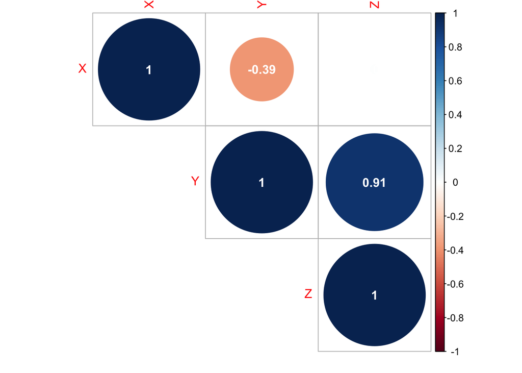

```r
library(corrplot)

my_df %>%
  select(X,Y,Z) %>%
  cor() %>%
  corrplot(.,
           method = "circle", # choose circle, square, ellipse, number, pie, shade, color
           type = "upper", # show only upper triangle of matrix
           addCoef.col="white") # add white numbers
```

# Regression

The primary task in econometrics is running a regression on data. Regression uses the linear model `lm()` command where “Y” is regressed on all X variables, connected with `+`s, where the data is sourced from your tibble.

```r
lm(Y~X+Z, data = my_df)
```

This will output the coefficients only. To get full information on coefficients, standard errors, hypothesis testing, and regression fit, pipe into the `summary()` command, or save the regression as an object and then run `summary()` on it. I show both methods below:

```r
my_df %>%
  lm(data = ., # pipes my_data into the data = argument
     Y~X+Z) %>%
  summary()
```

```
##
## Call:
## lm(formula = Y ~ X + Z, data = .)
##
## Residuals:
##     Min      1Q  Median      3Q     Max
## -5.2913 -0.8377 -0.0387  0.7535  3.7508
##
## Coefficients:
##             Estimate Std. Error t value Pr(>|t|)
## (Intercept) 13.51488    1.51898   8.897 3.22e-14 ***
## X           -4.65217    0.13328 -34.904  < 2e-16 ***
## Z            3.65230    0.04504  81.089  < 2e-16 ***
## ---
## Signif. codes:  0 '***' 0.001 '**' 0.01 '*' 0.05 '.' 0.1 ' ' 1
##
## Residual standard error: 1.397 on 97 degrees of freedom
## Multiple R-squared:  0.9876, Adjusted R-squared:  0.9874
## F-statistic:  3877 on 2 and 97 DF,  p-value: < 2.2e-16
```

```r
my_reg_1<-lm(Y~X+Z, data = my_df)
summary(my_reg_1)
```

```
##
## Call:
## lm(formula = Y ~ X + Z, data = my_df)
##
## Residuals:
##     Min      1Q  Median      3Q     Max
## -5.2913 -0.8377 -0.0387  0.7535  3.7508
##
## Coefficients:
##             Estimate Std. Error t value Pr(>|t|)
## (Intercept) 13.51488    1.51898   8.897 3.22e-14 ***
## X           -4.65217    0.13328 -34.904  < 2e-16 ***
## Z            3.65230    0.04504  81.089  < 2e-16 ***
## ---
## Signif. codes:  0 '***' 0.001 '**' 0.01 '*' 0.05 '.' 0.1 ' ' 1
##
## Residual standard error: 1.397 on 97 degrees of freedom
## Multiple R-squared:  0.9876, Adjusted R-squared:  0.9874
## F-statistic:  3877 on 2 and 97 DF,  p-value: < 2.2e-16
```

## Interpretation of Output

- The top row `Residuals` describes the distribution of the residuals.
- The `Coefficients` table describes the OLS parameters $\hat{\beta_j}$’s, where each row is a right-hand side variable, starting with `(Intercept)` $(\hat{\beta_0})$, then $(\hat{\beta_1})$, etc.
  - `Estimate` column describes the OLS parameters $(\hat{\beta_0}, \hat{\beta_1}, \cdots)$
  - `Std. Error` column describes the standard error of each parameter
  - `t value` column describes the test statistic for a hypothesis test where $H_0:$ that particular $\hat{\beta_j}=0$
  - `Pr(>|t|)` column is the $p$-value on that hypothesis test for that parameter (roughly, we’re looking for it to be less than 0.05, if it is, there will be `*` stars to the right of it.
- The bottomw three rows describes the goodness of fit of the regression
  - `Residual standard error` is the Standard Error of the Regression $\sigma_u$
  - `Multipled R-squared` is $R^2$, `Adjusted R-squared` is $\bar{R}^2$
  - `F-statistic` is the F-statistic on an *All F-test* (all betas are equal to 0), and associated `p-value` on that test

## Tidying Output with Broom

- The `broom` package allows us to output regressions into tidy tibbles that we can easily print, work with, and extract individual parameters or statistics from for further analysis

| Command | Does |
| --- | --- |
| `tidy()` | Takes the saved `reg_object` and makes a tibble of the coefficients table only |
| `augment()` | Create dataset with calculated values (e.g. `.fitted`, `.resid`) |
| `glance()` | Get statistics of regression fit (e.g. `r.squared`, `sigma`) |

```r
# load broom
library(broom)

# tidy to get coefficients in a tidy tibble
my_reg_1_tidy<-tidy(my_reg_1)
my_reg_1_tidy
```

| term | estimate | std.error | statistic | p.value |
| --- | --- | --- | --- | --- |
| (Intercept) | 13.514881 | 1.5189843 | 8.897315 | 3.217895e-14 |
| X | -4.652168 | 0.1332845 | -34.904031 | 1.022317e-56 |
| Z | 3.652303 | 0.0450404 | 81.089493 | 6.179655e-91 |

```r
# glance (original lm object) to view statistics
glance(my_reg_1)
```

| r.squared | adj.r.squared | sigma | statistic | p.value | df | logLik | AIC | BIC | deviance | df.residual |
| --- | --- | --- | --- | --- | --- | --- | --- | --- | --- | --- |
| 0.9876433 | 0.9873885 | 1.396836 | 3876.501 | 2.865786e-93 | 3 | -173.7919 | 355.5837 | 366.0044 | 189.2616 | 97 |

```r
# "r.squared" and "adj.r.squared" are self-explanatory
# "sigma" is the Standard Error of the Regression (SER)
# "statistic" is the F-statistic on the All-F test
# "p.value" is the p-value from that All-F test

my_reg_1_aug<-augment(my_reg_1)
my_reg_1_aug
```

| Y | X | Z | .fitted | .se.fit | .resid | .hat | .sigma | .cooksd | .std.resid |
| --- | --- | --- | --- | --- | --- | --- | --- | --- | --- |
| 9.5983924 | 9.737951 | 10.76144 | 7.516327 | 0.2479793 | 2.08206496 | 0.03151666 | 1.387389 | 2.488469e-02 | 1.51461685 |
| 2.5797834 | 11.785850 | 12.02853 | 2.616963 | 0.2934881 | -0.03717973 | 0.04414586 | 1.404087 | 1.141056e-05 | -0.02722482 |
| 4.9050850 | 10.334175 | 10.72002 | 4.591336 | 0.2443108 | 0.31374881 | 0.03059106 | 1.403716 | 5.474351e-04 | 0.22813040 |
| 24.6735406 | 9.028176 | 14.41761 | 24.171770 | 0.2086508 | 0.50177096 | 0.02231256 | 1.403137 | 1.004034e-03 | 0.36329556 |
| 34.4527179 | 9.371203 | 18.03719 | 35.795760 | 0.2190939 | -1.34304187 | 0.02460196 | 1.397216 | 7.968434e-03 | -0.97353865 |
| 21.3891870 | 10.272492 | 14.68002 | 19.341419 | 0.1419187 | 2.04776779 | 0.01032258 | 1.388286 | 7.550060e-03 | 1.47363003 |
| 32.4825115 | 9.568665 | 17.43714 | 32.685582 | 0.1915857 | -0.20307021 | 0.01881202 | 1.403936 | 1.376612e-04 | -0.14676574 |
| 24.6047291 | 10.740101 | 16.70255 | 24.552896 | 0.1738587 | 0.05183338 | 0.01549180 | 1.404082 | 7.336182e-06 | 0.03739852 |
| 24.9923687 | 9.709540 | 15.53710 | 25.090684 | 0.1535137 | -0.09831558 | 0.01207824 | 1.404056 | 2.043578e-05 | -0.07081343 |
| 22.3497797 | 10.018759 | 15.00197 | 21.697691 | 0.1412029 | 0.65208884 | 0.01021872 | 1.402498 | 7.577386e-04 | 0.46923645 |

[output cut: 90 more lines]

```r
# ".fitted" are predicted (Y-hat) values from the model
# ".resid" are the residuals (u-hat) for each X-value
```

- `augment` is particularly useful for plotting fitted or residual values, as in a residual plot, where you can set `aes(y = .resid)`.

## Extensions

### Categorical Data: Dummy Variables

For categorical data, you can run a regression with a dummy variable if that variable takes on the values of 0 or 1.

If the variable has multiple possible categories, you can use (or make) a dummy variable for *each* of the $n$ categories and include all $n-1$ dummy variables in the regression (to avoid the dummy variable trap!).

If your variable exists as a `factor` variable (e.g. the value of each observation for that variable is the name of the category), you can simply add that variable in the regression and R will automatically create a dummy for each category and include $n-1$ dummies in a regression:

```r
# run a regression with Shape, a factor variable
## which has "Circle," "Triangle," and "Square" for categories

shape_reg<-lm(Y~Shape, data = my_df)
summary(shape_reg)
```

```
##
## Call:
## lm(formula = Y ~ Shape, data = my_df)
##
## Residuals:
##     Min      1Q  Median      3Q     Max
## -33.446  -8.783  -0.010  10.234  21.661
##
## Coefficients:
##               Estimate Std. Error t value Pr(>|t|)
## (Intercept)     21.069      2.416   8.720 7.74e-14 ***
## ShapeSquare      0.206      3.032   0.068    0.946
## ShapeTriangle    1.319      3.450   0.382    0.703
## ---
## Signif. codes:  0 '***' 0.001 '**' 0.01 '*' 0.05 '.' 0.1 ' ' 1
##
## Residual standard error: 12.55 on 97 degrees of freedom
## Multiple R-squared:  0.00182,    Adjusted R-squared:  -0.01876
## F-statistic: 0.08841 on 2 and 97 DF,  p-value: 0.9155
```

```r
# Note R made two dummies:
# # ShapeTriangle for Triangle (0 or 1)
# # ShapeSquare for Square (0 or 1)
# # and left out Circle as the reference category
```

### Interaction Terms

To interact two variables in a regression and create an interaction term, simply add them to the regression with `:` or `*` between them.

```r
interact_reg<-lm(Y~X+Z+X:Z, data = my_df)
summary(interact_reg)
```

```
##
## Call:
## lm(formula = Y ~ X + Z + X:Z, data = my_df)
##
## Residuals:
##      Min       1Q   Median       3Q      Max
## -3.01411 -0.75425 -0.06623  0.81317  2.76908
##
## Coefficients:
##             Estimate Std. Error t value Pr(>|t|)
## (Intercept) 47.28197    5.33968   8.855 4.28e-14 ***
## X           -7.99364    0.52518 -15.221  < 2e-16 ***
## Z            1.28283    0.36586   3.506 0.000693 ***
## X:Z          0.23436    0.03599   6.511 3.41e-09 ***
## ---
## Signif. codes:  0 '***' 0.001 '**' 0.01 '*' 0.05 '.' 0.1 ' ' 1
##
## Residual standard error: 1.169 on 96 degrees of freedom
## Multiple R-squared:  0.9914, Adjusted R-squared:  0.9912
## F-statistic:  3701 on 3 and 96 DF,  p-value: < 2.2e-16
```

### Polynomial Models

To run a polynomial regression, simply add a higher order variable, which you can first `mutate()`, or use the `I()` command to create a quadratic (or higher order) term in your regression:

```r
reg_quad<-lm(Y~X+I(X^2), data = my_df)
summary(reg_quad)
```

```
##
## Call:
## lm(formula = Y ~ X + I(X^2), data = my_df)
##
## Residuals:
##     Min      1Q  Median      3Q     Max
## -20.487  -8.755  -1.634  11.213  19.902
##
## Coefficients:
##             Estimate Std. Error t value Pr(>|t|)
## (Intercept) -120.513     75.032  -1.606   0.1115
## X             32.862     14.779   2.224   0.0285 *
## I(X^2)        -1.839      0.724  -2.540   0.0127 *
## ---
## Signif. codes:  0 '***' 0.001 '**' 0.01 '*' 0.05 '.' 0.1 ' ' 1
##
## Residual standard error: 11.22 on 97 degrees of freedom
## Multiple R-squared:  0.203,  Adjusted R-squared:  0.1866
## F-statistic: 12.35 on 2 and 97 DF,  p-value: 1.663e-05
```

### Logarithmic Models

To run a regression with a logged variable, you can first `mutate()` the logged variable, or use the `log()` command to create a logged variable in your regression:

```r
reg_log_log<-lm(log(Y)~log(X), data = my_df)
summary(reg_log_log)
```

```
##
## Call:
## lm(formula = log(Y) ~ log(X), data = my_df)
##
## Residuals:
##     Min      1Q  Median      3Q     Max
## -2.9873 -0.2975  0.0962  0.6634  1.1164
##
## Coefficients:
##             Estimate Std. Error t value Pr(>|t|)
## (Intercept)  10.7762     1.9425   5.548 2.51e-07 ***
## log(X)       -3.4454     0.8396  -4.103 8.48e-05 ***
## ---
## Signif. codes:  0 '***' 0.001 '**' 0.01 '*' 0.05 '.' 0.1 ' ' 1
##
## Residual standard error: 0.85 on 97 degrees of freedom
##   (1 observation deleted due to missingness)
## Multiple R-squared:  0.1479, Adjusted R-squared:  0.1391
## F-statistic: 16.84 on 1 and 97 DF,  p-value: 8.482e-05
```

## Regression Output Tables

There are several methods to make regression output tables, but I have found best use with the `huxtable` package’s `huxreg()` command. There are three parts to the command (each separated by commas):

1. Add your regression `lm` objects, separated by commas.
- Optionally define a `"column name" = your_lm_object` for each.
2. Optionally rename and omit your X-variables as desired inside `coefs = c()`
- To change a variable’s name down each row, set `"desired name" = var_name`.
- Any X-variable not listed inside `coefs = c()` will be omitted from the table!
3. Optionally rename and omit statistics as desired inside `stats = c()`
- To change a variable’s name down each row, set `"desired name" = stat_name`.
- Any statistics not listed inside `stats = c()` will be omitted from the table!

```r
# default example
library(huxtable)
my_reg_1 %>% huxreg()
```

|  | (1) |
| --- | --- |
| (Intercept) | 13.515 *** |
|  | (1.519) |
| X | -4.652 *** |
|  | (0.133) |
| Z | 3.652 *** |
|  | (0.045) |
| N | 100 |
| R2 | 0.988 |
| logLik | -173.792 |
| AIC | 355.584 |
| *** p < 0.001; ** p < 0.01; * p < 0.05. |  |

```r
# heavily customized
library(huxtable)
huxreg(my_reg_1,
       shape_reg,
       interact_reg,
       reg_quad,
       reg_log_log,
       coefs = c("Constant" = "(Intercept)",
                 "X" = "X",
                 "Z" = "Z",
                 "Square" = "ShapeSquare",
                 "Triangle" = "ShapeTriangle",
                 "X:Z", "X:Z",
                 "$X^2$" = "I(X^2)",
                 "ln(X)" = "log(X)"),
       statistics = c("N" = "nobs",
                      "$R^2$" = "r.squared",
                      "SER" = "sigma"),
       note = NULL, # suppress footnote for stars, to insert Fixed Effects Row below
       number_format = 3) %>% # round to three decimals

  # Adding a lot of custom parts to table below

  add_rows(c("Fixed Effects", "None", "Shape", "None", "None", "None"), # add fixed effects row
         after = 17) %>% # insert after 17th row

  # allow math to render as R^2 and X^2
  set_escape_contents(c(14,20), c(1,1), FALSE) %>% # R^2 is rows 14 and 20, column 1

  # add centered "Y" in second row
  insert_row(c("",rep("Y",4)),"ln(Y)", after = 1) %>%
  merge_cells(c(2,2,2), 2:5) %>%

  # create borders
  set_all_borders(0) %>% # remove all borders to manually set my own
  set_top_border(1, 1:6, 2) %>% # add border size 2 to first row, columns 1:6
  set_top_border(2, 1:6, 1) %>% # add border size 1 to second row, columns 1:6
  set_top_border(3, 2:5, 1) %>% # add border size 1 to second row, columns 2:5
  set_top_border(19, 2:6, 1) %>% # add border size 1 to second row, columns 2:5
  set_bottom_border(22, 1:6, 2) %>% # add border size 2 to 22nd row, columns 1:6

  # caption the table
  set_caption( "Regression Results")
```

Regression Results

|  | (1) | (2) | (3) | (4) | (5) |
| --- | --- | --- | --- | --- | --- |
|  | Y |  |  |  | ln(Y) |
| Constant | 13.515 *** | 21.069 *** | 47.282 *** | -120.514 | 10.776 *** |
|  | (1.519) | (2.416) | (5.340) | (75.032) | (1.942) |
| X | -4.652 *** |  | -7.994 *** | 32.862 * |  |
|  | (0.133) |  | (0.525) | (14.779) |  |
| Z | 3.652 *** |  | 1.283 *** |  |  |
|  | (0.045) |  | (0.366) |  |  |
| Square |  | 0.206 |  |  |  |
|  |  | (3.032) |  |  |  |
| Triangle |  | 1.319 |  |  |  |
|  |  | (3.450) |  |  |  |
| X:Z |  |  | 0.234 *** |  |  |
|  |  |  | (0.036) |  |  |
| $X^2$ |  |  |  | -1.839 * |  |
|  |  |  |  | (0.724) |  |
| ln(X) |  |  |  |  | -3.445 *** |
|  |  |  |  |  | (0.840) |
| Fixed Effects | None | Shape | None | None | None |
| N | 100 | 100 | 100 | 100 | 99 |
| $R^2$ | 0.988 | 0.002 | 0.991 | 0.203 | 0.148 |
| SER | 1.397 | 12.554 | 1.169 | 11.218 | 0.850 |

# Plots

Plots of any kind can be made with `ggplot2`, which uses a “grammar of graphics” to build plots layer by layer. Some possible layers are described in the table below, *required* layers are boldened:

| Command | Layer | Description |
| --- | --- | --- |
| `data =` | **Data** | Defines what tibble to use for the data |
| `+aes()` | **Aesthetics** | Defines what variables from data will be mapped to markings |
| `+geom_*()` | **Geometry** | Defines what markings to make, e.g. `point`, `histogram`, `line`, `smooth` (for regression lines) |
| `+coord_*()` | Coordinates | Scales for axes |
| `+scale_*()` | Scales | Define the range of values |
| `+facet_*()` | Facets | Group into subplots |

### Histogram

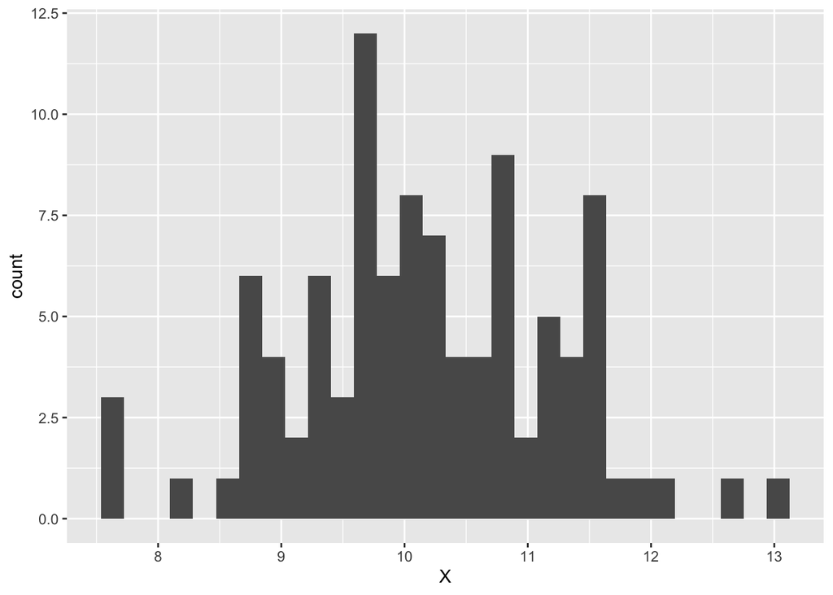

```r
ggplot(data = my_df)+
  aes(x = X)+
  geom_histogram()
```

### Scatterplot (with Regression Line)

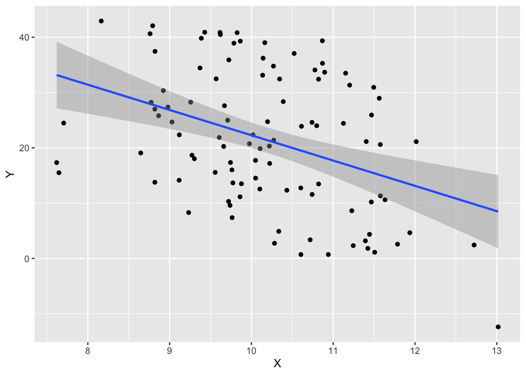

```r
ggplot(data = my_df)+
  aes(x = X,
      y = Y)+
  geom_point()+
  geom_smooth(method = "lm")
```

### Customized Example

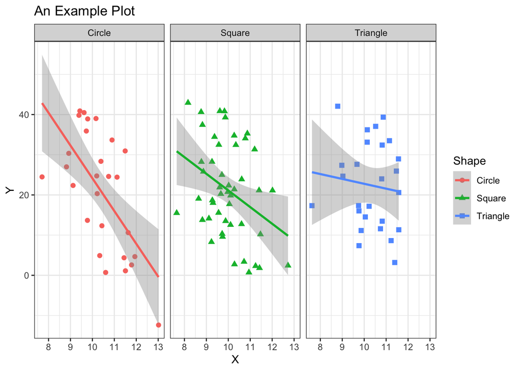

```r
ggplot(data = my_df)+
  aes(x = X,
      y = Y)+
  geom_point(aes(shape = Shape,
                 color = Shape),
             size = 2)+
  geom_smooth(method = "lm",
              aes(color = Shape))+
  labs(x = "X",
       y = "Y",
       title = "An Example Plot")+
  facet_wrap(~Shape)+
  theme_bw()
```

[^1]: With `library(tidyverse)`.
[^2]: Henceforth, with `tidyverse`, I refer to all `data.frame`s as `tibble`s
[^3]: Loading `tidyverse` automatically loads the `readr` package, allowing you to load`csv` and `tsv` files without loading any package. Other file types require loading other packages, such as `readxl` (for Excel files) or `haven` or `foreign` (which are pretty good at reading any other type).
[^4]: *Do not run this command in a markdown document or it will not knit!*